# Temperatura JP x CG

Dandara Sousa

```r
climas = read_csv(here::here("data/clima_cg_jp-semanal.csv"),
                  col_types = "cTdddddd")

#glimpse(climas)
```

**Um adendo: nem todos anos estão com informações semanais completas. O relatório abaixo foi feito com o máximo de dados possíveis para cada caso.**

## Temperatura

### Onde é mais quente?

Para obter os picos de calor seleciona-se cada temperatura máxima semanal nos dados. Após, agrupando as temperaturas por cidade e com um gráfico *beeswarm* é mais fácil enxergar qual cidade detém os maiores picos de calor. Enquanto João Pessoa teve no máximo temperaturas por volta de 33.5°, Campina Grande teve um pico de 34.5° e com várias semanas com temperaturas máximas acima do pico pessoense.

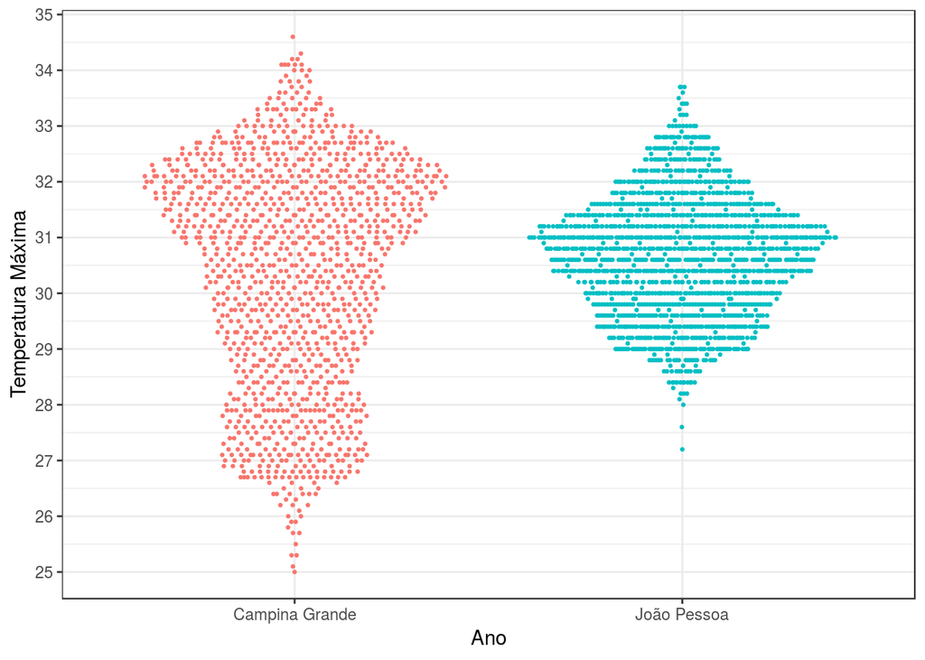

```r
climas %>%
  ggplot(mapping=aes(cidade,tmax, color = cidade)) +
  geom_quasirandom(size=.50) +
  scale_y_continuous(breaks = seq(25,35,1)) +
  theme(legend.position = "none") +
  labs(x = "Ano", y = "Temperatura Máxima")
```

As temperaturas máximas semanais (o pico do calor) são tão diferentes quanto as médias? Mais?

Quais os meses mais quentes e mais frios?

### Qual foi o São João mais frio de CG que está nos nossos dados?

Filtrando os dados para apenas a cidade de Campina Grande e no período entre 18 e 24 de junho (a semana do São João), o São João mais frio é aquele onde a temperatura mínima semanal foi a menor de todas. Para este caso, observando anualmente é visto que dois anos possuem esse marco de São João mais frio. São eles 1997 e 2018 com temperaturas mínimas de 16.6°.

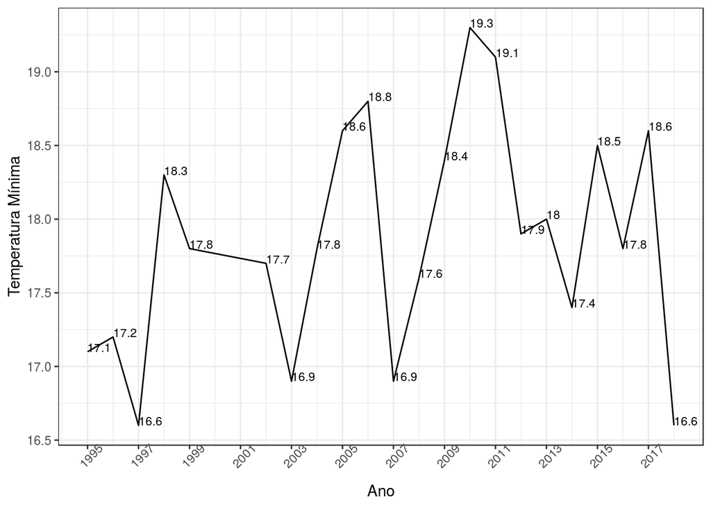

```r
climas %>%
  filter(cidade == "Campina Grande" & mes == 6 & day(as.Date(semana)) >= 18 & day(as.Date(semana)) <=24) %>%
  ggplot(aes(ano,tmin)) +
  geom_line() +
  geom_text(aes(label=tmin),hjust=0, vjust=0, size=3) +
  scale_x_continuous(breaks = seq(1995,2018,2)) +
  scale_y_continuous(breaks = seq(16,25,0.5)) +
  theme(axis.text.x = element_text(angle = 45))+
  labs(x = "Ano", y = "Temperatura Mínima")
```

## Chuva

Quanto chove por semana em JP e CG?

Como é a distribuição do volume de chuvas por semana em JP e CG? A chuva varia mais ou menos que a temperatura? O formato da distribuição é igual?

### No geral, onde chove mais?

Utilizando a mediana para representar o volume de chuva por ano em cada cidade, vê-se que a cidade de Campina Grande em geral tem menos chuva que em João Pessoa. Enquanto em João Pessoa o ano mais chuvoso foi em 2007 com 24mm, Campina Grande teve seu pico em 2004 com apenas 12mm.

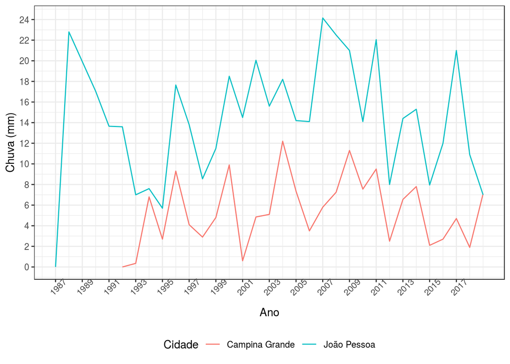

```r
climas %>%
  group_by(cidade, ano) %>%
  summarise(total_chuva = median(chuva)) %>%
  ggplot(aes(x= ano,y = total_chuva, colour = cidade)) +
  geom_line()  +
  scale_x_continuous(breaks = seq(1987,2018,2)) +
  scale_y_continuous(breaks = seq(0,25,2)) +
  theme(legend.position = "bottom",axis.text.x = element_text(angle = 45)) +
  labs(x = "Ano", y = "Chuva (mm)",colour = "Cidade")
```

Com relação ao volume total de chuva por ano, o gráfico abaixo utiliza como métrica o somatório de mms de chuva por cidade a cada ano. Este, reafirma a conclusão anterior que Campina Grande é uma cidade com menos chuva que João Pessoa.

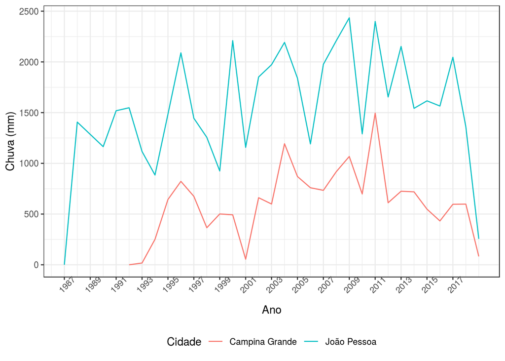

```r
climas %>%
  group_by(cidade, ano) %>%
  summarise(total_chuva = sum(chuva)) %>%
  ggplot(aes(x= ano,y = total_chuva, colour = cidade)) +
  geom_line()  +
  scale_x_continuous(breaks = seq(1987,2018,2)) +
  theme(legend.position = "bottom",axis.text.x = element_text(angle = 45)) +
  labs(x = "Ano", y = "Chuva (mm)",colour = "Cidade")
```

### A distribuição é diferente em meses específicos?

Agrupando por mês, no gráfico onde cada ponto é um ano, é perceptível que os meses entre setembro e dezembro são onde há um padrão de chuva para ambas a cidades. Enquanto em junho há uma dissiparidade grande no volume de chuva no decorrer dos anos principalmente para João Pessoa.

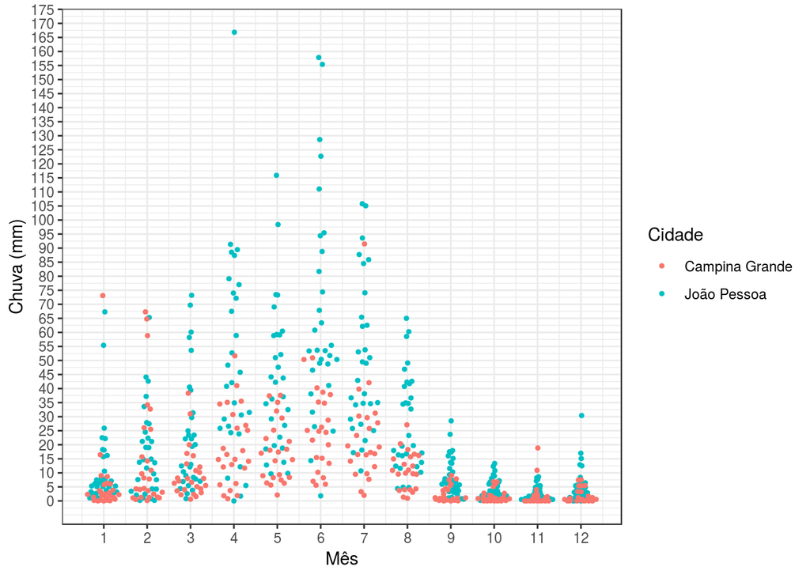

```r
climas %>%
  group_by(ano, mes, cidade) %>%
  summarise(total_chuva = median(chuva)) %>%
  ggplot(aes(x= mes,y = total_chuva)) +
  geom_quasirandom(size=.90, aes(colour = cidade))  +
  scale_x_continuous(breaks = seq(1,12)) +
  scale_y_continuous(breaks = seq(0,175,5)) +
  labs(x = "Mês", y = "Chuva (mm)",colour = "Cidade")
```